# BLAST analysis of the reference assembly

J. Ignacio Lucas Lledó

2025-03-05

## BLAST among contigs

```bash
if [ ! -e assembly.ndb ]; then
   makeblastdb -dbtype nucl \
               -in ../2023-05-15/assembly.fasta \
               -out assembly
fi

if [ ! -e selfblast.txt ]; then
   blastn -db assembly \
          -query ../2023-05-15/assembly.fasta \
          -out selfblast.txt \
          -outfmt "6 qacc sacc pident length qlen slen gaps evalue bitscore" \
          -evalue 1.0e-10 \
          -num_threads 24 \
          -max_hsps 1 \
          -max_target_seqs 2 1>blastn.out 2> blastn.err
   gawk '((/^contig/) && ($1 != $2)){
      print $0
   }' selfblast.txt > z1
   mv z1 selfblast.txt
fi
```

```r
library(Biostrings)
assembly <- readDNAStringSet('../2023-05-15/assembly.fasta')
info <- read.table(
   '../2023-05-12/flye/ONT_PB/assembly_info.txt',
   col.names = c('ctg', 'len', 'cov', 'circ', 'rep', 'mult', 'alt', 'graph'))
info <- info[match(names(assembly), info$ctg), 1:6]
selfblast <- read.table(
   'selfblast.txt',
   col.names = c('qacc', 'sacc', 'pident', 'length', 'qlen',
                 'slen', 'gaps', 'evalue', 'bitscore'))
info$besthit <- selfblast[match(info$ctg, selfblast$qacc), 'sacc']
info$reciprocal <- info[match(info$besthit, info$ctg), 'besthit']
info$is.rbh <- info$ctg == info$reciprocal
info[is.na(info$is.rbh), 'is.rbh'] <- FALSE
```

Only 71 contigs do not retrieve any BLAST hit among the other contigs. They all are shorter than average. Among the other 14469 contigs, which do find similarity in others, only a subset of 5283 are themselves the best *hits* for other contigs. That is, there is a small fraction of *reciprocal best hits*. Precisely, there are only 799 pairs of reciprocal best hits. Most contigs are not the best hit of their own best hit. And it is a fraction of all contigs which accumulate most of the hits. The difference in length could explain this pattern: if a long contig holds homology to three other contigs, it may be the best hit of all them, while only one of those can be its own best hit. Not worth checking.

### Self-alignable fraction of the genome

Taken together, all best hits (reciprocal or not), what fraction of the assembly do they represent? Ignoring the small contribution of gaps to the length of the alignments, alignment lengths add up to 26875752 bases. Taking into account that every alignment takes two sequences, the fraction of the genome that is included among best hits is half that number, namely 13437876, which represents 6.51% of the genome.

This is small enough to forget about it. Most of the assembly is quite unique.

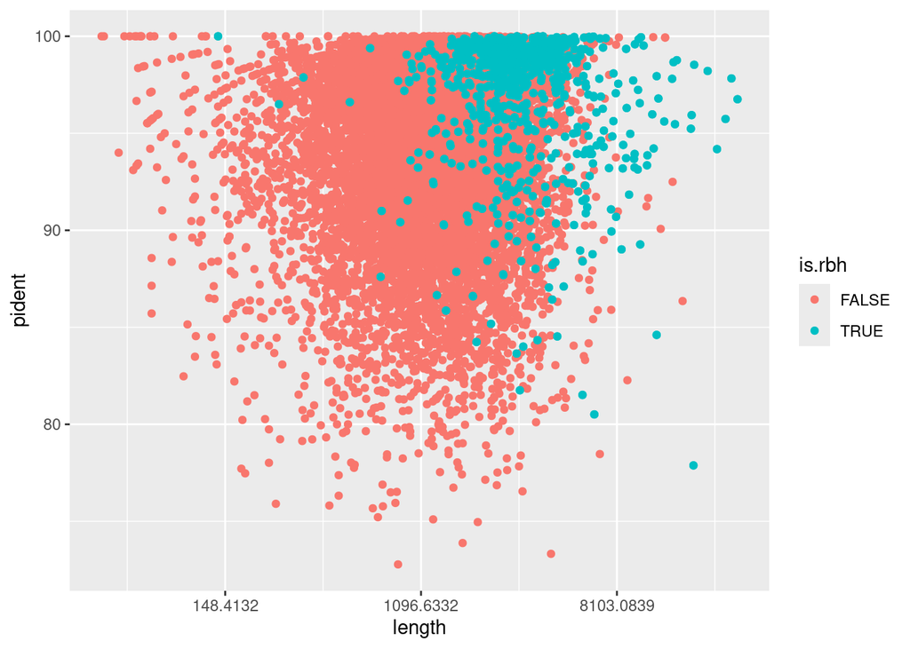

```r
library(ggplot2)
RBH <- info[info$is.rbh, 'ctg']
selfblast$is.rbh <- selfblast$qacc %in% RBH
selfblast <- selfblast[order(selfblast$is.rbh),]
ggplot(data = selfblast,
       mapping = aes(x = length, y = pident, color = is.rbh)) +
   geom_point() + scale_x_continuous(trans = 'log')
```

### Contigs where reads did not map

```bash
if [ ! -e used.txt ]; then
   grep -v '^#' ../2023-05-18/crepi.vcf | \
   cut -f 1 | uniq > used.txt
fi
```

```r
used <- scan('used.txt', what = 'character', quiet = TRUE)
info$used <- info$ctg %in% used
info$uniq <- is.na(info$besthit)
table(info[, c('used', 'uniq')])
```

```
##        uniq
## used    FALSE  TRUE
##   FALSE   142    21
##   TRUE  14327    50
```

Among the 14540 contigs in the assembly, most of them get ddRAD reads mapped to them: 14377. The 163 which did not constitute only the 0.24% of the assembly’s length. Quite irrelevant.

## BLAST of contigs to the non-redudant nucleotide data base

```bash
export BLASTDB=$BLASTDB:/opt/blastdb/
if [ ! -e assembly2nt.txt ]; then
   ~/bin/ncbi-blast-2.16.0+/bin/blastn -db /opt/blastdb/nt \
          -query ../2023-05-15/assembly.fasta \
          -out assembly2nt.txt \
          -outfmt "6 qacc sacc pident length evalue bitscore ssciname sblastname" \
          -evalue 1.0e-6 \
          -num_threads 24 \
          -max_hsps 1 \
          -max_target_seqs 1 1>blastn2.out 2> blastn2.err
fi
```